# Taxonomic Coverage

Charlotte R. Patterson

2023-06-28

This code calculates the taxonomic coverage of the SCAR Antarctic Terrestrial Biodiversity Database. Taxonomic coverage is assessed by first assigning taxa to expert-defined functional groups (Priority Threat Management Groups, or ‘PTMs’; Lee et al. 2022), then grouping functional groups into ‘priority’ groups for modelling. These priority groups are also expert-defined (Lee et al. 2022) and separate out groups that are (1) at risk, and (2) have a poorly known geographic distribution. Finally, we count the number of records available per group as a proxy to assess whether that group could be modelled.

## Initial setup

Load packages and set working directory.

```r
library(tidyverse)

packages <- c("here", "gridExtra")

walk(packages, require, character.only = T)

here::here()
```

## Load data

Read in the cleaned biodiversity database (cleaned in file “Terrestrial_Antarctic_Biodiversity_Database_Cleaning.Rmd”).

```r
# Load biodiversity data as dataframe
Ant_biodf <- read.csv(here("Data/Ant_Terr_Bio_Data_Uncertainty_Terms_Removed_August_2023.csv"))
```

## Count the number of records per functional group

```r
# dynamicProperties indicates whether a species is vagrant
PTM_count <- count(Ant_biodf, PTM_ID, PTM_NAME, scientificNameClean, dynamicProperties)

# Make sure there's no white space
Ant_biodf$PTM_NAME <- str_trim(Ant_biodf$PTM_NAME)

# Remove vagrant species or vagrant records of a species
Ant_biodf <- Ant_biodf %>%
    filter(dynamicProperties != c("Vagrant species"))

# Remove those records that weren't able to be grouped into a PTM (PTM ID = ?)
# Now separate out PTM IDs into four columns, as some records have up to four PTMs that they are listed under
Ant_biodf_PTM <- Ant_biodf %>%
  filter(PTM_ID != "?") %>%
  separate(PTM_ID, into = c("PTM_1", "PTM_2", "PTM_3", "PTM_4"), sep = "&") %>%
  .[, 30:33]

# Now count the total number of records per PTM across all columns
Ant_biodf_PTM_count <- data.frame(table(unlist(Ant_biodf_PTM[c("PTM_1", "PTM_2", "PTM_3", "PTM_4")])))

# Rename
colnames(Ant_biodf_PTM_count) <- c("PTM_ID", "Freq")

# Setting PTM IDs as numeric
Ant_biodf_PTM_count$PTM_ID <- as.numeric(levels(Ant_biodf_PTM_count$PTM_ID))[Ant_biodf_PTM_count$PTM_ID]

# Summing all records per PTM as some were split across rows
Ant_biodf_PTM_final <- Ant_biodf_PTM_count %>% dplyr::group_by(PTM_ID) %>%
  dplyr::summarize(Freq = sum(Freq))
```

## Assign functional groups their priority status

Load a .csv file with the two priority grouping variables (‘intactness’ and ‘wallacean’ - whether the group has a wallacean shortfall, i.e. their distribution is poorly known) assigned to each PTM.

```r
# Load priority groupings
PTM_priority <- read.csv(here("Data/PTM_rankings.csv"))

PTM_priority$PTM_ID <- as.character(PTM_priority$PTM_ID)

Ant_biodf_PTM_final$PTM_ID <- as.character(Ant_biodf_PTM_final$PTM_ID)

# Match functional groups with their priority status
freq_intactness_wallacean <- full_join(Ant_biodf_PTM_final, PTM_priority, by = "PTM_ID")

# Assign NAs as Not assessed
freq_intactness_wallacean$intactness[is.na(freq_intactness_wallacean$intactness)] <- "Not assessed"

freq_intactness_wallacean$wallacean[is.na(freq_intactness_wallacean$wallacean)] <- "Not assessed"

# Remove a small number of vagrant and non-terrestrial species
freq_intactness_wallacean <- freq_intactness_wallacean %>%
  filter(name != "vagrants") %>%
  filter(name != "Vagrants") %>%
  filter(name != "Invasive") %>%
  filter(name != "Sea spiders") %>%
  filter(name != "Marine algae") %>%
  filter(name != "Marine invertebrates") %>%
  filter(name != "Marine plankton") %>%
  filter(name != "Fish")

# Assign groups to frequency levels
freq_intactness_wallacean <- freq_intactness_wallacean %>%
  mutate(type = ifelse(Freq < 100, "< 100", "")) %>%
  mutate(type = ifelse(Freq > 100 & Freq < 500, "> 100 to 500", type)) %>%
  mutate(type = ifelse(Freq > 500 & Freq < 1000, "> 500 to 1000", type)) %>%
  mutate(type = ifelse(Freq > 1000, "> 1000", type))

# Relabel priority groups for plotting
freq_intactness_wallacean <- freq_intactness_wallacean %>%
  mutate(Priority = if_else(intactness == "Decline" & wallacean == 1, "Both",
                            if_else(intactness == "Decline", "At risk",
                                    if_else(wallacean == 1, "Distribution poorly known",
                                            if_else(intactness == "Not assessed", "Not assessed", "Neither")))))
```

## Print frequency of records per functional group

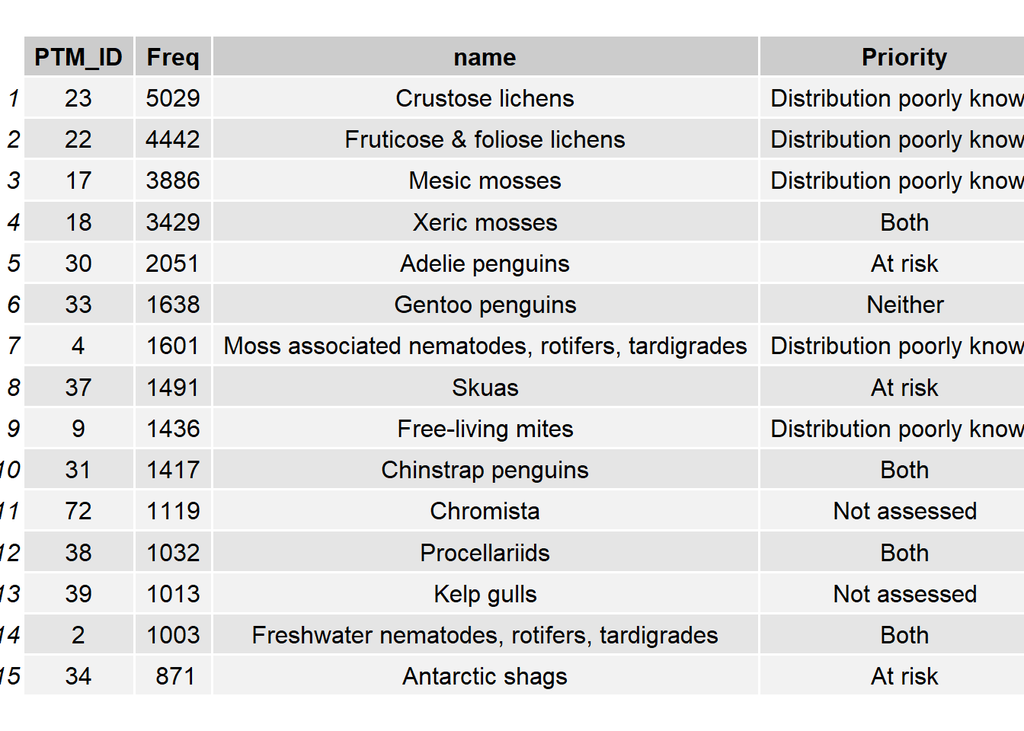

```r
freq_intactness_wallacean %>%
  arrange(desc(Freq)) %>%
  .[1:15, c("PTM_ID", "Freq", "name", "Priority")] %>%
  grid.table()
```

# Print frequency of records for priority groups

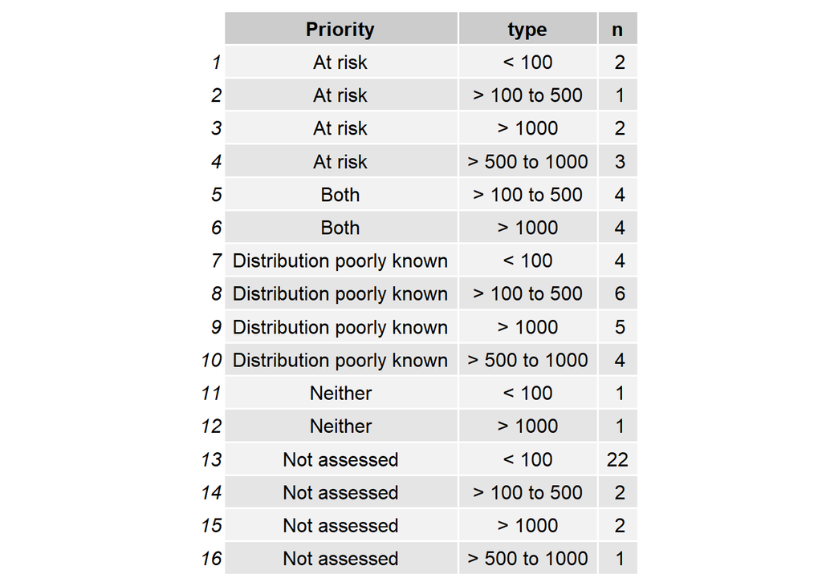

```r
freq_intactness_wallacean %>%
  count(Priority, type) %>%
  grid.table()
```

## Plotting number of records per priority group

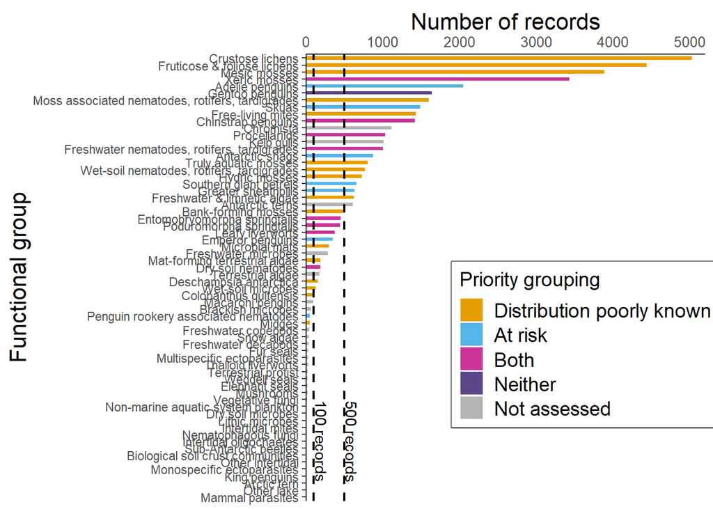

```r
# Reorder factor for plotting
freq_intactness_wallacean$Priority <- factor(freq_intactness_wallacean$Priority,
                                   levels = c("Distribution poorly known",
                                              "At risk",
                                              "Both",
                                              "Neither",
                                              "Not assessed"))


PTM_priority_plot<- freq_intactness_wallacean %>%
  arrange(-desc(Freq)) %>%
  mutate(name = factor(name, name)) %>%
  ggplot() +
  geom_bar(stat = "identity", aes(fill = Priority), position = "dodge", width = 0.5)+
  aes(x = name, y = Freq,label = Freq) +
  scale_y_continuous(expand = c(0,0), limits = c(0, 5200), position = "right")+
  labs(x = "Functional group", y = "Number of records", fill = "Priority grouping") +
  scale_fill_manual(values = c("#E69F00","#56B4E9","#CC3399", "mediumpurple4", "gray70"))+
  geom_hline(yintercept = 100, linetype = "dashed", linewidth = 0.8) +
  geom_hline(yintercept = 500, linetype = "dashed", linewidth = 0.8) +
  theme_classic()+
  coord_flip()+
  theme(axis.text.y=element_text(size = 8.5),
        axis.text.x=element_text(size = 10),
        axis.ticks.x=element_blank(),
        axis.title.x=element_text(size = 16, vjust = -0.5),
        axis.title.y = element_text(size=16, vjust = 0.8),
        legend.text = element_text(size=14),
        legend.title = element_text(size=14),
        panel.grid.major = element_blank(),
        panel.grid.minor = element_blank(),
        strip.text = element_text(size = 11.75),
        legend.position = c(.7, .35),
        legend.box.background = element_rect(colour = "black",
                                             linewidth = 0.7)) +
  annotate("text", x = 9, y = 200, label = "100 records", angle = '270') +
  annotate("text", x = 8.9, y = 600, label = "500 records", angle = '270')


PTM_priority_plot
```

```r
# ggsave(plot = PTM_priority_plot, filename = here("Outputs/PTM_priority_plot.jpg"), w = 20, h = 23, units = "cm", dpi = 800, device = "jpeg" )
```

## References

Lee, J.R., Terauds, A., Carwardine, J., Shaw, J.D., Fuller, R.A., Possingham, H.P., Chown, S.L., Convey, P., Gilbert, N., Hughes, K.A., McIvor, E., Robinson, S.A., Ropert-Coudert, Y., Bergstrom, D.M., Biersma, E.M., Christian, C., Cowan, D.A., Frenot, Y., Jenouvrier, S., Kelley, L., Lee, M.J., Lynch, H.J., Njåstad, B., Quesada, A., Roura, R.M., Shaw, E.A., Stanwell-Smith, D., Tsujimoto, M., Wall, D.H., Wilmotte, A., Chadès, I., 2022a. Threat management priorities for conserving Antarctic biodiversity. PLOS Biology 20, e3001921.